# Hausarbeit_Statistik_WiSe2425_Louis-Hollmann_Lukas-Pierchalla

Louis Hollmann (591467), Lukas Pierchalla (592515)

2025-01-12

# Einleitung

Die vorliegende Analyse untersucht Kraftstoffpreise in Berlin mithilfe von statistischen Methoden. Ziel ist es, Trends, Unterschiede zwischen Tankstellen sowie Einflussfaktoren auf die Preise zu identifizieren. Hierzu werden die Kraftstoffpreise für E5, E10 und Diesel analysiert und mit verschiedenen Merkmalen wie Tankstellenmarken, Wochentagen und Feiertagen in Beziehung gesetzt. Die Analyse basiert auf einem Datensatz, der die Kraftstoffpreise für verschiedene Tankstellen in Berlin über einen Zeitraum von fast einem Jahr enthält.

Weitere Informationen und der vollständige Ordner ist auf [GitHub](https://github.com/LupierHN/statistikWiSe2425) verfügbar.

# Import und erste Überprüfung der Daten

Der Datensatz wird in R importiert und auf fehlende Werte überprüft. Erste Maßnahmen werden ergriffen, um fehlende Werte und Inkonsistenz zu identifizieren und zu korrigieren.

```r
# Daten importieren
datensatz <- read.csv2("tankerkoenigWS2024.csv", header = TRUE, sep = ",", dec = ".")
```

## Fehlende Werte

```r
# Summe der fehlenden Werte anzeigen
print(sum(is.na(datensatz)))
```

```
## [1] 9065
```

Die Gesamtanzahl der fehlenden Werte wurde ermittelt. Hierdurch fällt auf, dass fehlende Werte existieren welche behandelt werden müssen, ebenfalls ist die Anzahl dieser nun bekannt. Um weitere Maßnahmen zu ergreifen wird überprüft, welche Spalten betroffen sind und wie viele fehlende Werte es in den einzelnen Spalten gibt.

```r
# Spalten mit Anzahl der fehlender Werte anzeigen
print(colSums(is.na(datensatz)))
```

```
##             X            id          date          time          name
##             0             0             0             0             0
##         brand        street  house_number     post_code  opening_time
##             0             0          9065             0             0
##  closing_time     e5_median    e10_median diesel_median
##             0             0             0             0
```

Dies lässt darauf schließen, dass lediglich in der Spalte “house_number” fehlende Werte existieren. Um die Ursache für die fehlenden Werte zu ermitteln, werden die ersten 5 Zeilen des Datensatzes mit fehlenden Werten überprüft.

```r
# Erste 5 Zeilen mit fehlenden Werten anzeigen
print(datensatz[!complete.cases(datensatz),][1:5,])
```

```
##            X                                   id       date     time
## 62207 156864 01abf2e9-84e2-4328-936f-9958c7c733a8 2023-01-01 06:00:00
## 62208 156865 01abf2e9-84e2-4328-936f-9958c7c733a8 2023-01-01 07:00:00
## 62209 156866 01abf2e9-84e2-4328-936f-9958c7c733a8 2023-01-01 08:00:00
## 62210 156867 01abf2e9-84e2-4328-936f-9958c7c733a8 2023-01-01 09:00:00
## 62211 156868 01abf2e9-84e2-4328-936f-9958c7c733a8 2023-01-01 10:00:00
##                  name brand                 street house_number post_code
## 62207 Esso Tankstelle  ESSO UNTER DEN EICHEN 67-69         <NA>     12203
## 62208 Esso Tankstelle  ESSO UNTER DEN EICHEN 67-69         <NA>     12203
## 62209 Esso Tankstelle  ESSO UNTER DEN EICHEN 67-69         <NA>     12203
## 62210 Esso Tankstelle  ESSO UNTER DEN EICHEN 67-69         <NA>     12203
## 62211 Esso Tankstelle  ESSO UNTER DEN EICHEN 67-69         <NA>     12203
##       opening_time closing_time e5_median e10_median diesel_median
## 62207     06:00:00     22:00:00      1899       1839          2009
## 62208     06:00:00     22:00:00      1859       1799          1954
## 62209     06:00:00     22:00:00      1839       1779          1889
## 62210     06:00:00     22:00:00      1849       1789          1889
## 62211     06:00:00     22:00:00      1804       1744          1844
```

Die ersten 5 Zeilen mit fehlenden Werten zeigen, dass die fehlenden Werte in der Spalte “house_number” auftreten, wenn die Spalte “street” eine Hausnummer enthält. Um die fehlenden Werte zu korrigieren, werden die Hausnummern aus der Spalte “street” extrahiert und in die Spalte “house_number” eingesetzt. Nach der Anpassung des Datensatzes wird überprüft, ob die Anpassung erfolgreich war und ob noch weitere fehlende Werte vorhanden sind. Hierfür wird exemplarisch eine Zeile mit fehlerhaften Werten vor und nach der Anpassung des Datensatzes angezeigt.

```r
# Zeile vor Anpassung des Datensatzes
print(datensatz[datensatz$X == 156865, c("street", "house_number")])
```

```
##                       street house_number
## 62208 UNTER DEN EICHEN 67-69         <NA>
```

```r
# Erster Versuch Anpassung des Datensatzes um formattierung zu korrigieren
for (i in seq_len(nrow(datensatz))) {
  if (is.na(datensatz$house_number[i]) && grepl("\\d", datensatz$street[i])) {
    datensatz$house_number[i] <- sub(".*?(\\d.*)", "\\1", datensatz$street[i]) # Extrahiert Hausnummer
    datensatz$street[i] <- sub("(.*?)(\\d.*)", "\\1", datensatz$street[i]) # Beibehält nur die Straße
  }
}
# Zeile nach Anpassung des Datensatzes
print(datensatz[datensatz$X == 156865, c("street", "house_number")])
```

```
##                  street house_number
## 62208 UNTER DEN EICHEN         67-69
```

```r
# Prüfen ob alle fehlenden Werte korrigiert wurden
print(sum(is.na(datensatz)))
```

```
## [1] 0
```

Da die fehlenden Werte erfolgreich korrigiert wurden, sind keine fehlerhaften Werte mehr im Datensatz vorhanden. Der Datensatz ist bereit für die weitere Analyse.

## Überprüfung der Daten auf Inkonsistenzen

Zu Beginn wird ein Überblick über den Inhalt des Datensatzes verschafft und die 5-Punkte-Zusammenfassung der numerischen Variablen angezeigt und überprüft.

```r
print(summary(datensatz))
```

```
##        X               id                date               time
##  Min.   :     1   Length:172338      Length:172338      Length:172338
##  1st Qu.:108095   Class :character   Class :character   Class :character
##  Median :214334   Mode  :character   Mode  :character   Mode  :character
##  Mean   :213621
##  3rd Qu.:321497
##  Max.   :428902
##      name              brand              street          house_number
##  Length:172338      Length:172338      Length:172338      Length:172338
##  Class :character   Class :character   Class :character   Class :character
##  Mode  :character   Mode  :character   Mode  :character   Mode  :character
##
##
##
##    post_code     opening_time       closing_time         e5_median
##  Min.   :10585   Length:172338      Length:172338      Min.   :1579
##  1st Qu.:12349   Class :character   Class :character   1st Qu.:1799
##  Median :12621   Mode  :character   Mode  :character   Median :1839
##  Mean   :12835                                         Mean   :1843
##  3rd Qu.:13467                                         3rd Qu.:1884
##  Max.   :14195                                         Max.   :2279
##    e10_median   diesel_median
##  Min.   :1539   Min.   : 839
##  1st Qu.:1739   1st Qu.:1649
##  Median :1784   Median :1719
##  Mean   :1784   Mean   :1726
##  3rd Qu.:1829   3rd Qu.:1799
##  Max.   :2239   Max.   :2099
```

Bei der 5-Punkte-Zusammenfassung der Diesel-Preise fällt auf das Ausreißer existieren. Dies wird durch den überdurchschnittlichen Abstand des kleinsten Wertes zum 1. Quartil besonders deutlich. Um die Ausreißer besser zu erkennen, wird ein Boxplot der Diesel-Preise verwendet.

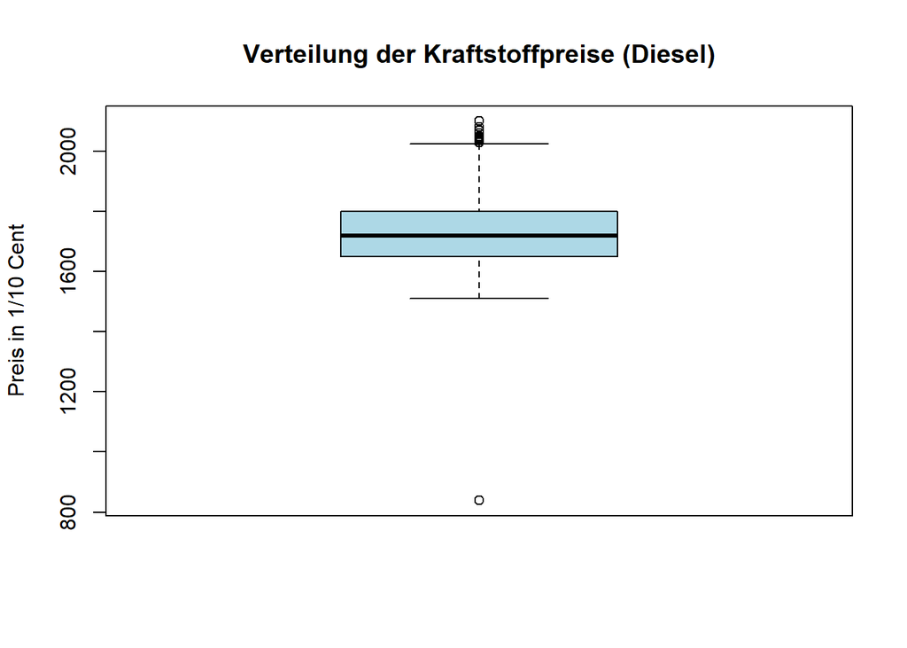

```r
# Werteverteilung der Spalte "diesel_median"
boxplot(datensatz$diesel_median, main = "Verteilung der Kraftstoffpreise (Diesel)", ylab = "Preis in 1/10 Cent", col = "lightblue")
```

Dem angezeigten Boxplot ist zu entnehmen das Ausreißer in der Spalte “diesel_median” vorhanden sind. Da der Ausreißer bei ca. 80 Cent liegt und keine vergleichbaren Werte in der Nähe vorhanden sind, wird der Ausreißer als fehlerhafter Wert betrachtet. Um die Daten zu bereinigen und unser Ergebnis nicht zu verfälschen, wird der fehlerhafte Wert entfernt.

```r
# Ausreißer entfernen
datensatz <- datensatz[datensatz$diesel_median > 1000,]
# Erneute Überprüfung der Daten
print(summary(datensatz$diesel_median))
```

```
##    Min. 1st Qu.  Median    Mean 3rd Qu.    Max.
##    1509    1649    1719    1726    1799    2099
```

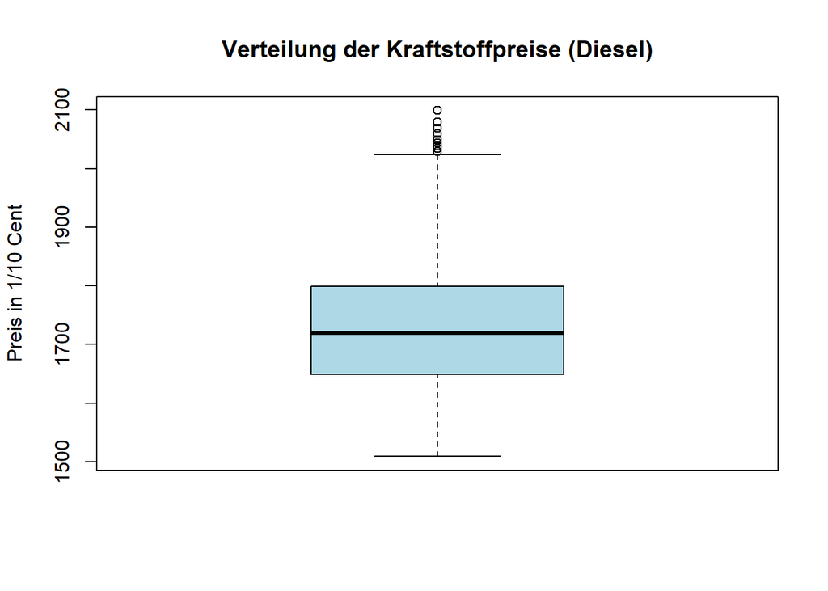

```r
boxplot(datensatz$diesel_median, main = "Verteilung der Kraftstoffpreise (Diesel)", ylab = "Preis in 1/10 Cent", col = "lightblue")
```

Der fehlerhafte Wert wurde erfolgreich entfernt und die Verteilung der Kraftstoffpreise für Diesel wurde korrigiert. Die 5-Punkte-Zusammenfassung sowie der Boxplot der Daten Diesel weisen keine weiteren Inkonsistenzen auf und der Datensatz ist bereit für die weitere Analyse.

## Exploration der Daten

Um die Struktur sowie den Inhalt der Daten nachzuvollziehen werden die ersten 5 Zeilen des Datensatzes angezeigt.

```r
head(datensatz, 5)
```

```
##   X                                   id       date     time             name
## 1 1 005056a9-779e-1ee9-81a5-0ae97d8d86da 2023-01-01 06:00:00 ORLEN Tankstelle
## 2 2 005056a9-779e-1ee9-81a5-0ae97d8d86da 2023-01-01 07:00:00 ORLEN Tankstelle
## 3 3 005056a9-779e-1ee9-81a5-0ae97d8d86da 2023-01-01 08:00:00 ORLEN Tankstelle
## 4 4 005056a9-779e-1ee9-81a5-0ae97d8d86da 2023-01-01 09:00:00 ORLEN Tankstelle
## 5 5 005056a9-779e-1ee9-81a5-0ae97d8d86da 2023-01-01 10:00:00 ORLEN Tankstelle
##   brand            street house_number post_code opening_time closing_time
## 1 ORLEN Mariendorfer Damm        306.0     12107     06:00:00     22:00:00
## 2 ORLEN Mariendorfer Damm        306.0     12107     06:00:00     22:00:00
## 3 ORLEN Mariendorfer Damm        306.0     12107     06:00:00     22:00:00
## 4 ORLEN Mariendorfer Damm        306.0     12107     06:00:00     22:00:00
## 5 ORLEN Mariendorfer Damm        306.0     12107     06:00:00     22:00:00
##   e5_median e10_median diesel_median
## 1      1849       1789          1949
## 2      1839       1779          1929
## 3      1879       1819          1959
## 4      1814       1754          1879
## 5      1769       1709          1829
```

Folgende Inhalte sind im Datensatz enthalten und werden tabellarisch dargestellt:

| X | id | date | time | name | brand | street | house_number | post_code | opening_time | closing_time | e5_median | e10_median | diesel_median |
| --- | --- | --- | --- | --- | --- | --- | --- | --- | --- | --- | --- | --- | --- |
| ID der Zeile | ID der Tankstelle | Datum der Beobachtung | Uhrzeit der Beobachtung | Name der Tankstelle | Marke der Tankstelle | Straße der Tankstelle | Hausnummer der Tankstelle | Postleitzahl der Tankstelle | Öffnungszeit der Tankstelle | Schließzeit der Tankstelle | Medianpreis für Kraftstoff E5 | Medianpreis für Kraftstoff E10 | Medianpreis für Kraftstoff Diesel |

# Allgemeine Untersuchung

## Erste Überprüfung der Daten

Für eine erste Überprüfung der Daten werden Anzahl der Tankstellen, Beobachtungen, Marken, Straßen, Postleitzahlen, Öffnungszeiten, Schließzeiten und Daten ermittelt. Dazu werden die Anzahl der einzigartigen Werte in den jeweiligen Spalten gezählt.

```r
uebersicht <- data.frame(
  Kategorie = c("Anzahl der Tankstellen", "Anzahl der Beobachtungen", "Anzahl der Marken", "Anzahl der Straßen", "Anzahl der Postleitzahlen", "Anzahl der Öffnungszeiten", "Anzahl der Schließzeiten", "Anzahl der Daten"),
  Anzahl = c(length(unique(datensatz$id)), nrow(datensatz), length(unique(datensatz$brand)), length(unique(datensatz$street)), length(unique(datensatz$post_code)), length(unique(datensatz$opening_time)), length(unique(datensatz$closing_time)), length(unique(datensatz$date)))
)

print(uebersicht)
```

```
##                   Kategorie Anzahl
## 1    Anzahl der Tankstellen     37
## 2  Anzahl der Beobachtungen 172337
## 3         Anzahl der Marken      9
## 4        Anzahl der Straßen     35
## 5 Anzahl der Postleitzahlen     34
## 6 Anzahl der Öffnungszeiten      5
## 7  Anzahl der Schließzeiten      7
## 8          Anzahl der Daten    259
```

Die Daten umfassen 37 Tankstellen, 9 Marken, 35 Straßen, 34 Postleitzahlen, 5 Öffnungszeiten, 7 Schließzeiten und 259 einzigartige Datumswerte, was sie gut für statistische Analysen geeignet macht. Der Vergleich der Marken ist aufgrund der ausreichend großen Datenbasis aussagekräftig. Im Gegensatz dazu ist der Vergleich von Tankstellen und Postleitzahlen aufgrund der geringen Datenbasis weniger geeignet; eine Gruppierung auf Bezirksebene könnte hier sinnvoller sein. Die lange Erhebungsdauer der 259 Datumswerte erlaubt es, zeitliche Trends und Entwicklungen zuverlässig zu untersuchen.

## Häufigkeitsverteilung der Preise

Nun wird die Häufigkeitsverteilung der Kraftstoffpreise für E5, E10 und Diesel untersucht. Dazu werden Histogramme für jeden Kraftstofftyp erstellt welche die Verteilungen der Preise anzeigen. Hiermit wird ein Vergleich der Preisverteilung zwischen den Kraftstoffarten ermöglicht.

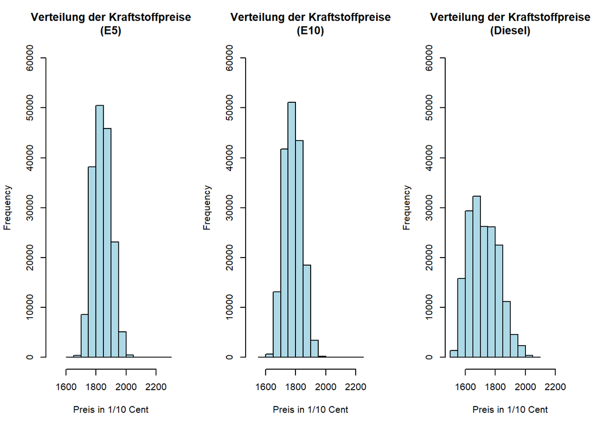

```r
# Histogramme für jeden Kraftstofftyp auf gleicher Skala
par(mfrow = c(1, 3))
hist(datensatz$e5_median, main = "Verteilung der Kraftstoffpreise\n(E5)", xlab = "Preis in 1/10 Cent", col = "lightblue", breaks = 15, ylim = c(0, 60000), xlim = c(1500, 2300))
hist(datensatz$e10_median, main = "Verteilung der Kraftstoffpreise\n(E10)", xlab = "Preis in 1/10 Cent", col = "lightblue", breaks = 15, ylim = c(0, 60000), xlim = c(1500, 2300))
hist(datensatz$diesel_median, main = "Verteilung der Kraftstoffpreise\n(Diesel)", xlab = "Preis in 1/10 Cent", col = "lightblue", breaks = 15, ylim = c(0, 60000), xlim = c(1500, 2300))
```

Aus den Histogrammen ist erkennbar, dass die Verteilungen der Kraftstoffpreise für E5 und E10 ähnlich sind, während die Verteilung der Dieselpreise davon abweicht. Dies legt nahe, dass die Preise für E5 und E10 stärker miteinander korrelieren könnten als die Preise für Diesel.

Die äußeren Bereiche der Verteilungen für E5 und E10 zeigen ähnliche Muster: Der Anstieg der Preise ist nahezu symmetrisch. Diesel hingegen weist eine asymmetrische Verteilung auf. Es gibt nur wenige günstigere Ausreißer, aber eine deutlich höhere Anzahl Ausreißer im teureren Bereich.

Der Schwerpunkt der Preise liegt bei: - E5: etwa 182 Cent, - E10: etwa 177 Cent, - Diesel: etwa 167 Cent. Dies bestätigt, dass die Preise für E5 und E10 tendenziell höher liegen als die Dieselpreise. Gleichzeitig könnte die stärkere Streuung bei Diesel darauf hindeuten, dass externe Faktoren wie Marktbedingungen oder Steuerregelungen einen größeren Einfluss auf dessen Preisgestaltung haben.

Anhand einer abweichenden Gruppierung werden neue Histogramme erstellt, um die Verteilung der Kraftstoffpreise genauer zu untersuchen.

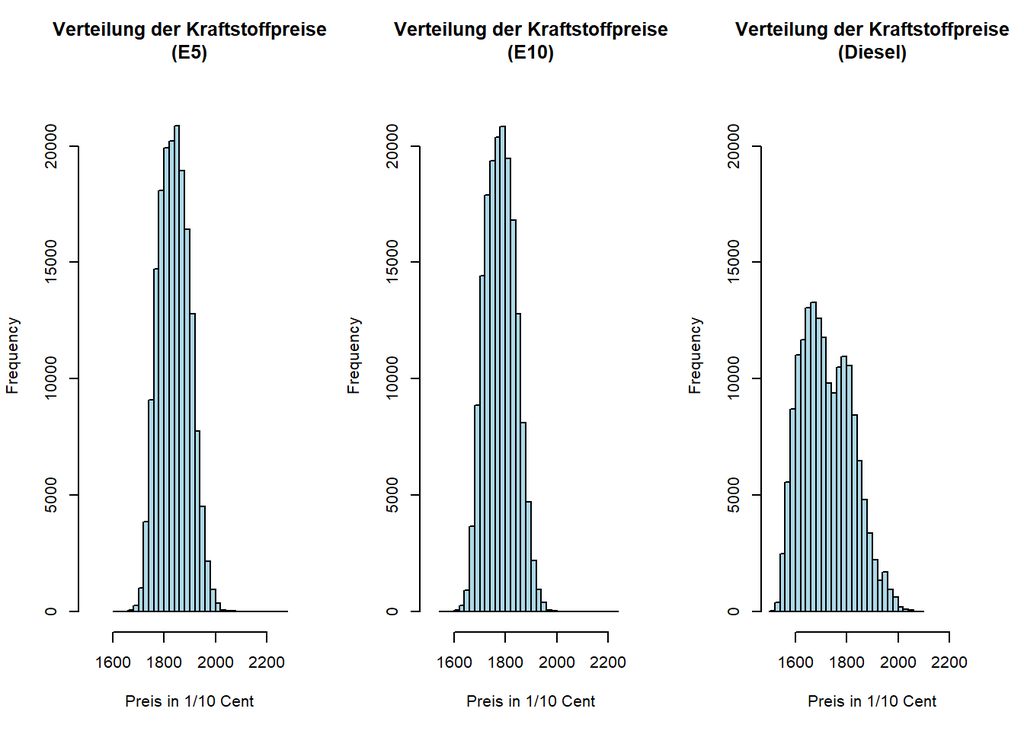

```r
par(mfrow = c(1, 3))
hist(datensatz$e5_median, main = "Verteilung der Kraftstoffpreise\n(E5)", xlab = "Preis in 1/10 Cent", col = "lightblue", breaks = 25, ylim = c(0, 22000), xlim = c(1500, 2300))
hist(datensatz$e10_median, main = "Verteilung der Kraftstoffpreise\n(E10)", xlab = "Preis in 1/10 Cent", col = "lightblue", breaks = 25, ylim = c(0, 22000), xlim = c(1500, 2300))
hist(datensatz$diesel_median, main = "Verteilung der Kraftstoffpreise\n(Diesel)", xlab = "Preis in 1/10 Cent", col = "lightblue", breaks = 25, ylim = c(0, 22000), xlim = c(1500, 2300))
```

Die neuen Histogramme mit kleineren Gruppierungen bestätigen unsere bisherige Überprüfung der Kraftstoffpreise von E5 und E10. Bei Diesel zeigt sich eine Diskrepanz zum vorherigen Histogramm. Anstatt von einem Peak bei ca. 167 Cent zeigt sich nun ein weiterer Peak bei ca. 180 Cent. Außerdem ist erkennbar, dass die Dieselpreisverteilung deutlich rechtsschief ist. Dies bedeutet, dass es mehr Preise gibt, die sich im günstigeren Bereich befinden als im teureren Bereich.

### Untersuchung der Streuung der Kraftstoffpreise

Anschließend werden die Medianpreise, das arithmetische Mittel und die Standardabweichung für E5, E10 und Diesel berechnet und verglichen.

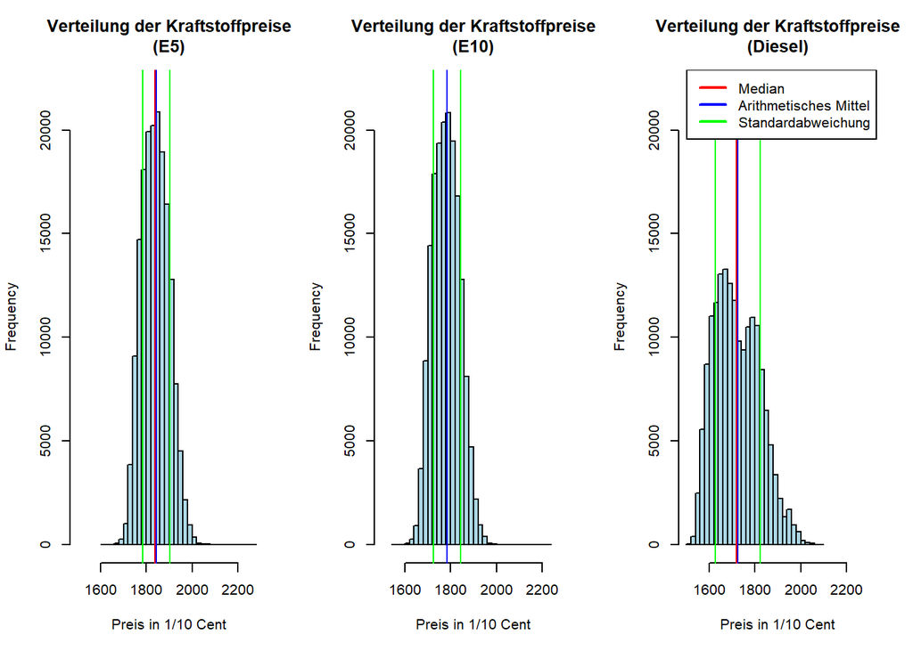

```r
par(mfrow = c(1, 3))
hist(datensatz$e5_median, main = "Verteilung der Kraftstoffpreise\n(E5)", xlab = "Preis in 1/10 Cent", col = "lightblue", breaks = 25, ylim = c(0, 22000), xlim = c(1500, 2300))
abline(v = median(datensatz$e5_median), col = "red", lwd = 1)
abline(v = mean(datensatz$e5_median), col = "blue", lwd = 1)
abline(v = mean(datensatz$e5_median) + sd(datensatz$e5_median), col = "green", lwd = 1)
abline(v = mean(datensatz$e5_median) - sd(datensatz$e5_median), col = "green", lwd = 1)
hist(datensatz$e10_median, main = "Verteilung der Kraftstoffpreise\n(E10)", xlab = "Preis in 1/10 Cent", col = "lightblue", breaks = 25, ylim = c(0, 22000), xlim = c(1500, 2300))
abline(v = median(datensatz$e10_median), col = "red", lwd = 1)
abline(v = mean(datensatz$e10_median), col = "blue", lwd = 1)
abline(v = mean(datensatz$e10_median) + sd(datensatz$e10_median), col = "green", lwd = 1)
abline(v = mean(datensatz$e10_median) - sd(datensatz$e10_median), col = "green", lwd = 1)
hist(datensatz$diesel_median, main = "Verteilung der Kraftstoffpreise\n(Diesel)", xlab = "Preis in 1/10 Cent", col = "lightblue", breaks = 25, ylim = c(0, 22000), xlim = c(1500, 2300))
abline(v = median(datensatz$diesel_median), col = "red", lwd = 1)
abline(v = mean(datensatz$diesel_median), col = "blue", lwd = 1)
abline(v = mean(datensatz$diesel_median) + sd(datensatz$diesel_median), col = "green", lwd = 1)
abline(v = mean(datensatz$diesel_median) - sd(datensatz$diesel_median), col = "green", lwd = 1)
legend("topright", legend = c("Median", "Arithmetisches Mittel", "Standardabweichung"), col = c("red", "blue", "green"), lty = 1, lwd = 2)
```

In einer ersten grafischen Darstellung werden die Medianpreise, das arithmetische Mittel und die Standardabweichung für E5, E10 und Diesel verglichen. Die rote Linie zeigt den Median, die blaue Linie das arithmetische Mittel und die grünen Linien die Standardabweichung. Es ist zu erkennen, dass die Standardabweichung bei Diesel am höchsten ist, was auf eine größere Streuung der Preise hinweist. Die Standardabweichung bei E5 und E10 ist geringer, was auf eine stabilere Preisentwicklung hindeutet. Der Medianpreis für E5 und E10 liegt nahe beieinander, während der Medianpreis für Diesel niedriger ist. Dies bestätigt die Beobachtungen aus den vorherigen Histogrammen.

Um nicht nur grafisch, sondern auch in tabellarischer Form die Unterschiede zwischen den Kraftstoffarten zu analysieren, werden die Medianpreise, das arithmetische Mittel und die Standardabweichung für E5, E10 und Diesel berechnet und in einer Tabelle dargestellt.

```r
# Medianpreise, arithmetisches Mittel und Standardabweichung für E5, E10 und Diesel
bez <- c("E5", "E10", "Diesel")
masd <- data.frame(bez, c(median(datensatz$e5_median), median(datensatz$e10_median), median(datensatz$diesel_median)), round(c(mean(datensatz$e5_median), mean(datensatz$e10_median), mean(datensatz$diesel_median)), 2), round(c(sd(datensatz$e5_median), sd(datensatz$e10_median), sd(datensatz$diesel_median)), 2))
colnames(masd) <- c("Kraftstoff", "Median", "Arithmetisches Mittel", "Standardabweichung")
masd
```

```
##   Kraftstoff Median Arithmetisches Mittel Standardabweichung
## 1         E5   1839               1843.16              58.89
## 2        E10   1784               1784.32              58.82
## 3     Diesel   1719               1726.11              98.35
```

Die Tabelle zeigt, dass die Standardabweichung bei E5 und E10 fast identisch ist, während sie bei Diesel deutlich höher ist. Dies bestätigt die Beobachtungen aus den Histogrammen und Boxplots. Der Medianpreis für E5 und E10 liegt sehr nah beim jeweiligen arithmetischen Mittel, während der Medianpreis für Diesel etwas niedriger ist. Dies ist durch die höhere Streuung der Dieselpreise zu erklären.

Als letzter Schritt wird die Streuung der Kraftstoffpreise für E5, E10 und Diesel in einem Boxplot dargestellt, um die Unterschiede in der Verteilung der Preise zu verdeutlichen.

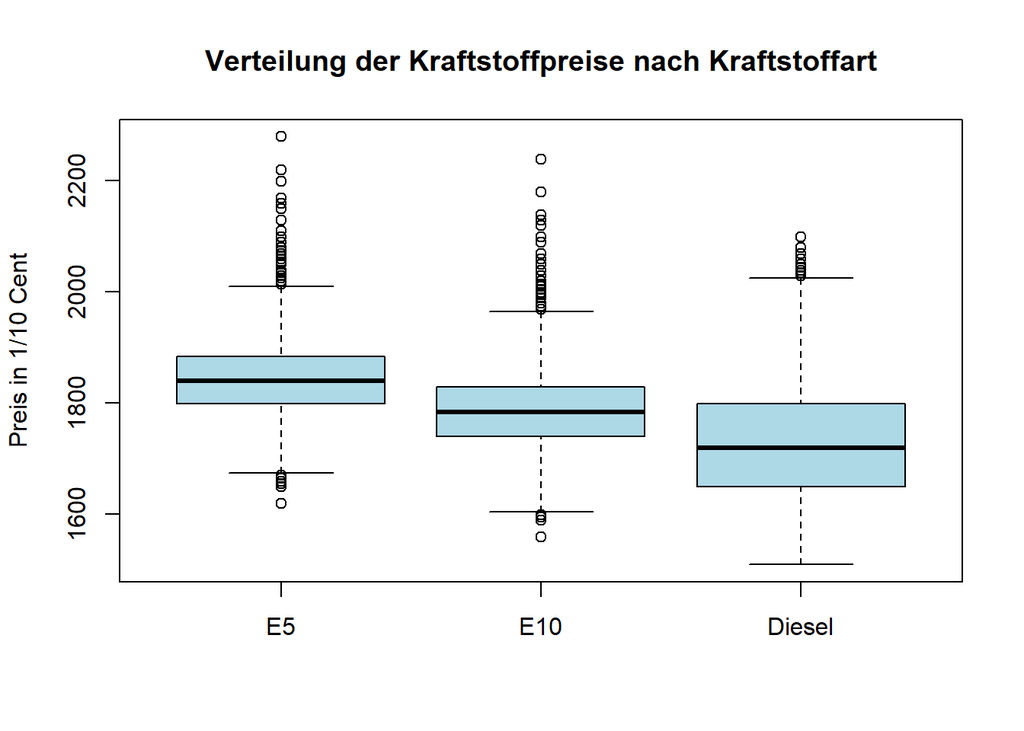

```r
# Verteilung der Kraftstoffpreise nach Kraftstoffart
boxplot(cbind(datensatz$e5_median, datensatz$e10_median, datensatz$diesel_median), main = "Verteilung der Kraftstoffpreise nach Kraftstoffart", ylab = "Preis in 1/10 Cent", col = "lightblue", names = c("E5", "E10", "Diesel"))
```

#### E5 und E10

Die Boxplots zeigen, dass die Preisverteilung von E5 und E10 insgesamt sehr ähnlich ist. Jedoch ist E5 tendenziell etwas teurer als E10. Die Streuung der Preise (IQR) ist bei beiden Kraftstoffarten vergleichbar, was auf eine parallele Preisentwicklung hindeutet. Auffällig sind in beiden Fällen einige starke Ausreißer im oberen Preisbereich.

## Zeitliche Entwicklung der Kraftstoffpreise

Der Preisverlauf der drei Kraftstoffarten E5, E10 und Diesel wird über die Zeit untersucht. Dazu werden die durchschnittlichen Preise für jeden Tag berechnet und in einem Liniendiagramm dargestellt. Als zusätzliche Information werden die Schulferien in Berlin für das Jahr 2023 in das Diagramm eingefügt, sowie die durchschnittlichen Preise für E5, E10 und Diesel als gestrichelte Linie.

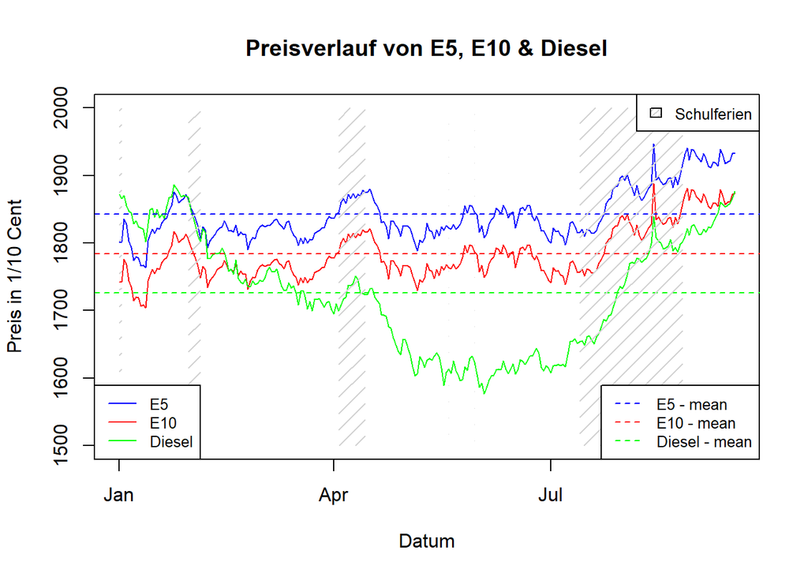

```r
# Preisverlauf über Zeit der drei Kraftstoffarten für jeden Tag der durchschnittliche Preis
# Daten vorbereiten
datensatz$date <- as.Date(datensatz$date)
#Schulferien in Berlin importieren
schulferien <- read.csv2("SchulferienBerlin2023.csv", header = TRUE, sep = ";", dec = ".")
schulferien$StartDate <- as.Date(schulferien$StartDate, format = "%d/%m/%y")
schulferien$EndDate <- as.Date(schulferien$EndDate, format = "%d/%m/%y")
# Durchschnittliche Preise für jeden Tag berechnen
durchschnittspreise <- aggregate(datensatz[,c("e5_median", "e10_median", "diesel_median")], by = list(datensatz$date), FUN = mean)
plot(durchschnittspreise$Group.1, durchschnittspreise$e5_median, type = "l", col = "blue", xlab = "Datum", ylab = "Preis in 1/10 Cent", main = "Preisverlauf von E5, E10 & Diesel", ylim = c(1500, 2000))
lines(durchschnittspreise$Group.1, durchschnittspreise$e10_median, col = "red")
lines(durchschnittspreise$Group.1, durchschnittspreise$diesel_median, col = "green")
abline(h = c(1843.16, 1784.32, 1726.11), col = c("blue", "red", "green"), lty = 2)
for (i in seq_len(nrow(schulferien))) {
  rect(schulferien$StartDate[i], 1500, schulferien$EndDate[i], 2000, col = "lightgrey", border = NA, density = 10)
}
legend("bottomleft", legend = c("E5", "E10", "Diesel"), col = c("blue", "red", "green"), lty = 1, cex = 0.8)
legend("topright", legend = "Schulferien", fill = "lightgrey", density = 25, cex = 0.8)
legend("bottomright", legend = c("E5 - mean", "E10 - mean", "Diesel - mean"), col = c("blue", "red", "green"), lty = 2, cex = 0.8)
```

Aus dem Liniendiagramm ist ersichtlich, dass die Preise für E5 und E10 über den Zeitraum zwar schwankungen unterliegen, aber die Preise für Diesel viel stärkere Schwankungen zeigen. Die durchschnittlichen Preise für E5 und E10 zeigen eine ähnliche Entwicklung, dies deutet darauf hin, dass die Preise für E5 und E10 miteinander korrelieren. Die Preise für Diesel hingegen weisen eine stärkere Varianz auf. Die Schulferien in Berlin sind im Diagramm als graue hervorgehoben dargestellt. Es ist zu erkennen, dass die Preise während der Schulferien in 2 von 3 Fällen auffällig ansteigen. Dies könnte darauf hindeuten, dass die Nachfrage nach Kraftstoff während der Ferienzeit steigt und die Preise entsprechend angepasst werden. Die vorherige Untersuchung der Kraftstoffpreise zeigte, dass die E5 Preise tendenziell höher sind als die E10 Preise. Dies wird durch das Liniendiagramm bestätigt, da die durchschnittlichen Preise für E5 über den gesamten Zeitraum über denen von E10 liegen. Diesel hingegen weist die niedrigsten Preise auf, was ebenfalls mit den vorherigen Ergebnissen übereinstimmt. Eine Ausnahme bildet der Zeitraum vor Februar, in dem die Diesel Preise kurzzeitig über denen von E5 liegen. Ab Mai sinken die Diesel Preise jedoch wieder und liegen weit unter denen von E5 und E10.

### Korrelation zwischen den Kraftstoffpreisen

Um den Zusammenhang zwischen den Kraftstoffpreisen zu untersuchen, wird die Korrelation zwischen E5, E10 und Diesel berechnet. Dazu wird der Korrelationskoeffizient nach Pearson verwendet und die Ergebnisse in einer Tabelle dargestellt.

```r
cor(datensatz[,c("e5_median", "e10_median", "diesel_median")], method = "pearson")
```

```
##               e5_median e10_median diesel_median
## e5_median     1.0000000  0.9963372     0.5239985
## e10_median    0.9963372  1.0000000     0.5240526
## diesel_median 0.5239985  0.5240526     1.0000000
```

Die Kraftstoffe E5 und E10 Korrelieren mit einem Korrelationskoeffizienten von 0.9963 (sehr hoher Zusammenhang) wogegen Diesel eine Korrellation von ca. 0.52 (hoher Zusammenhang) mit den anderen Kraftstoffen aufweist.

### Fazit zur allgemeinen Untersuchung

Die hohe Korrelation zwischen E5 und E10 kommt nicht überraschend, da die beiden Kraftstoffarten auf dem gleichen Rohstoff basieren und daher ähnliche Preisentwicklungen aufweisen. Dies und der höhere Preis von E5 im Vergleich zu E10 kommt daher, dass E5 einen niedrigeren Bioethanolanteil hat (95 % Benzin 5 % Bioethanol) und daher teurer ist. *Quelle: https://www.autoscout24.de/informieren/ratgeber/kfz-technik/e10-tanken/* Diesel hingegen hat eine geringere Korrelation mit E5 und E10, da es sich zum einen um einen anderen Kraftstoff handelt und zum anderen die Preisgestaltung von Diesel von anderen Faktoren abhängt. So ist ein Grund für die niedrigeren Dieselpreise die geringere Besteuerung von Dieselkraftstoff im Vergleich zu Benzin. Die Energiesteuer pro Liter Diesel beträgt 47,04 Cent, während sie für Benzin 65,45 Cent beträgt. Dies führt dazu, dass Dieselkraftstoff in der Regel günstiger ist als Benzin. *Quelle: https://www.adac.de/verkehr/tanken-kraftstoff-antrieb/tipps-zum-tanken/7-fragen-zum-benzinpreis/* Die geringen Dieselpreise ab Mai sind auf die sehr niedrigen Rohölnotierungen zurückzuführen, die zu einem Preisverfall bei Diesel geführt haben. *Quelle: https://presse.adac.de/meldungen/adac-ev/verkehr/diesel-im-mai-auf-jahrestiefststand.html*

# Untersuchung von Einflussfaktoren

Es wurden bereits Unterschiede zwischen den Kraftstoffpreisen festgestellt. Nun sollen mögliche Einflussfaktoren auf die Preisentwicklung untersucht werden. Dazu werden Hypothesen aufgestellt und überprüft.

## Hypothese 1 - Unterschiede im Preisverhalten zwischen Wochentagen

Es wird vermutet, dass die Kraftstoffpreise an Montagen stabiler sind als an Freitagen. Die Vermutung basiert auf der Annahme, dass die Preise zu Beginn der Woche weniger stark schwanken als am Ende der Woche, da die Nachfrage an Montagen tendenziell geringer ist. Um die Hypothese zu überprüfen, wird die Varianz der Kraftstoffpreise an verschiedenen Wochentagen berechnet und miteinander verglichen.

### Untersuchung der Hypothese 1

Um die Varianz der Kraftstoffpreise an verschiedenen Wochentagen zu berechnen, werden die Daten nach Wochentagen gruppiert und die Varianz der Preise für E5, E10 und Diesel berechnet. Anschließend werden die Ergebnisse in einem Barplot dargestellt.

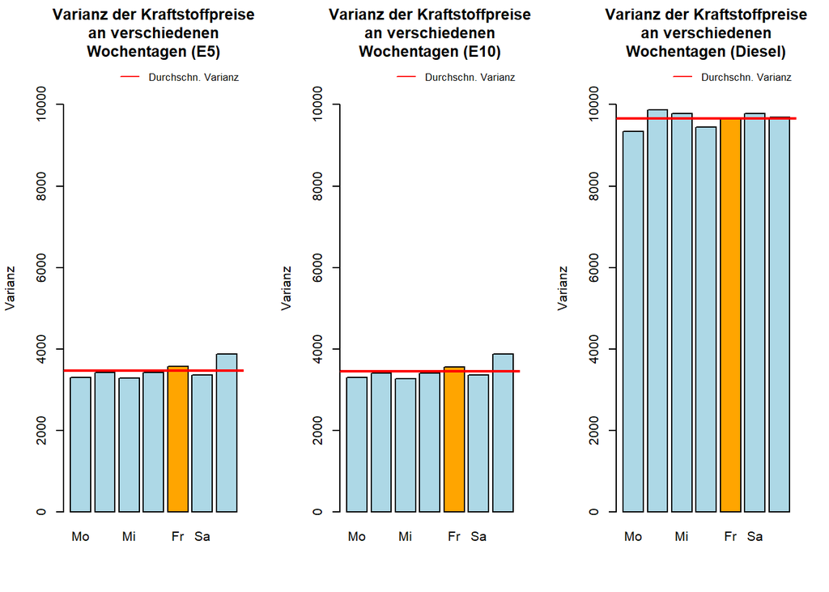

```r
# Daten nach Wochentagen gruppieren
datensatz$day <- weekdays(datensatz$date)
# Varianz der Kraftstoffpreise an verschiedenen Wochentagen berechnen
varianz <- aggregate(datensatz[,c("e5_median", "e10_median", "diesel_median")], by = list(datensatz$day), FUN = var)
varianz_e5 <- varianz$e5_median
varianz_e10 <- varianz$e10_median
varianz_diesel <- varianz$diesel_median
names(varianz_e5) <- varianz$Group.1
names(varianz_e10) <- varianz$Group.1
names(varianz_diesel) <- varianz$Group.1
# Sortierung der Wochentage (Montag bis Sonntag)
varianz_e5 <- varianz_e5[c("Montag", "Dienstag", "Mittwoch", "Donnerstag", "Freitag", "Samstag", "Sonntag")]
varianz_e10 <- varianz_e10[c("Montag", "Dienstag", "Mittwoch", "Donnerstag", "Freitag", "Samstag", "Sonntag")]
varianz_diesel <- varianz_diesel[c("Montag", "Dienstag", "Mittwoch", "Donnerstag", "Freitag", "Samstag", "Sonntag")]
# Wochentage Abkürzen
names(varianz_e5) <- c("Mo", "Di", "Mi", "Do", "Fr", "Sa", "So")
names(varianz_e10) <- c("Mo", "Di", "Mi", "Do", "Fr", "Sa", "So")
names(varianz_diesel) <- c("Mo", "Di", "Mi", "Do", "Fr", "Sa", "So")
# Dreifacher Barplot der Varianz der Kraftstoffpreise an verschiedenen Wochentagen nach Kraftstoffart
par(mfrow = c(1, 3))
barplot(varianz_e5, main = "Varianz der Kraftstoffpreise\nan verschiedenen\nWochentagen (E5)", ylab = "Varianz", col = ifelse(names(varianz_e5) == "Fr", "orange", "lightblue"), ylim = c(0, 11000))
abline(h = mean(varianz_e5), col = "red", lwd = 2)
legend("topright", legend = "Durchschn. Varianz", col = "red", lty = 1, bty = "n", cex = 0.8)
barplot(varianz_e10, main = "Varianz der Kraftstoffpreise\nan verschiedenen\nWochentagen (E10)", ylab = "Varianz", col = ifelse(names(varianz_e10) == "Fr", "orange", "lightblue"), ylim = c(0, 11000))
abline(h = mean(varianz_e10), col = "red", lwd = 2)
legend("topright", legend = "Durchschn. Varianz", col = "red", lty = 1, bty = "n", cex = 0.8)
barplot(varianz_diesel, main = "Varianz der Kraftstoffpreise\nan verschiedenen\nWochentagen (Diesel)", ylab = "Varianz", col = ifelse(names(varianz_diesel) == "Fr", "orange", "lightblue"), ylim = c(0, 11000))
abline(h = mean(varianz_diesel), col = "red", lwd = 2)
legend("topright", legend = "Durchschn. Varianz", col = "red", lty = 1, bty = "n", cex = 0.8)
```

Die drei Barplots visualisieren die Varianz der Kraftstoffpreise für E5, E10 und Diesel an verschiedenen Wochentagen. Die orangefarbenen Balken markieren die Werte für Freitage, während die blauen Balken die übrigen Wochentage repräsentieren. Die rote Linie stellt die durchschnittliche Varianz über alle Wochentage hinweg dar und bietet eine klare Referenz für den Vergleich der Freitage mit dem Durchschnitt sowie mit anderen Wochentagen. Die durchschnittliche Varianz beträgt für E5 etwa 3464, für E10 etwa 3456 und für Diesel etwa 9655.

Die Analyse der Barplots zeigt, dass die Varianz der Kraftstoffpreise an Freitagen häufig über dem Durchschnitt liegt. Dies deutet darauf hin, dass die Preise an Freitagen stärkeren Schwankungen unterliegen als an den meisten anderen Tagen. Besonders auffällig ist, dass die Varianz der Preise für E5 und E10 an Sonntagen die höchsten Werte erreicht. Dies könnte auf spezifische Marktbedingungen oder Nachfrageveränderungen an Sonntagen hinweisen. Im Gegensatz dazu sind die Preisvariationen unter der Woche für E5 und E10 relativ stabil.

Die Varianz der Dieselpreise ist insgesamt an allen Wochentagen höher als die von E5 und E10. Dies bestätigt die Erkenntnis, dass Dieselpreise stärkeren Schwankungen ausgesetzt sind. Interessanterweise zeigt Diesel eine andere Dynamik: Die höchste Varianz tritt an Dienstagen auf, während Montags die geringste Varianz beobachtet wird. Im Gegensatz zu E5 und E10 lässt sich bei Diesel keine eindeutige Tendenz in den Schwankungen über die Wochentage hinweg erkennen.

### Fazit zur Hypothese 1

#### Schwankungen der Kraftstoffpreise an Freitagen

Die Analyse der Varianz der Kraftstoffpreise an verschiedenen Wochentagen zeigt, dass die Preise an Freitagen tendenziell stärkeren Schwankungen unterliegen als an den meisten anderen Tagen. Dies bestätigt die Hypothese, dass die Kraftstoffpreise an Freitagen instabiler sind als an anderen Wochentagen. Eine mögliche Erklärung dafür könnte sein, dass an Freitagen eine erhöhte Nachfrage besteht, da viele Verbraucher vor dem Wochenende tanken. Dies kann zu stärkeren Preisbewegungen führen, wenn Tankstellenbetreiber auf die gestiegene Nachfrage reagieren. Für Verbraucher bedeutet dies eine erhöhte Unsicherheit, da die Preise an Freitagen weniger vorhersehbar sind als an anderen Tagen. Dies kann dazu führen, dass Verbraucher an Freitagen höhere Preise zahlen als an anderen Wochentagen.

#### Höchste Schwankungen an Sonntagen (E5 und E10)

An Sonntagen zeigt sich deutlich die höchste Varianz der Kraftstoffpreise für E5 und E10. Dies könnte darauf hindeuten, dass an Sonntagen spezifische Marktbedingungen oder Nachfrageveränderungen vorliegen, die zu stärkeren Preisschwankungen führen. Eine mögliche Erklärung könnte sein, dass durch logistische Einschränkungen das Angebot limitierter ist und die Preise entsprechend angepasst werden. Außerdem könnte ebenfalls eine erhöhte Nachfrage an Sonntagen, aufgrund des anstehenden Arbeitsbeginns am Montag, zu Preisschwankungen führen. Für Verbraucher bedeutet dies, dass sie an Sonntagen mit besonders hohen Preisschwankungen rechnen müssen und gegebenenfalls von einem Tanken an diesem Tag absehen sollten.

#### Unterschiedliche Dynamik bei Diesel

Im Gegensatz zu E5 und E10 zeigen die Dieselpreise keine klare Tendenz hinsichtlich stabilerer oder stärker schwankender Preise an bestimmten Wochentagen. Während die Varianz an Dienstagen am höchsten ist, ist sie an Montagen am niedrigsten, ohne dass ein erkennbares Muster über die Woche hinweg besteht. Dies deutet darauf hin, dass die Preisentwicklung von Diesel von anderen Faktoren abhängt als die von E5 und E10. Möglicherweise spielen externe Einflüsse wie Rohölpreise oder Steuerregelungen eine größere Rolle bei der Preisgestaltung von Diesel. Verbraucher sollten daher bei Dieselpreisen mit stärkeren Schwankungen rechnen und gegebenenfalls flexibel auf Preisänderungen reagieren.

## Hypothese 2 - Mondphase-Effekt

Eine weitere Hypothese besagt, dass die Kraftstoffpreise in Berlin von den Mondphasen beeinflusst werden. Es wird vermutet, dass die Preise an Vollmondtagen höher sind als an anderen Tagen. Die Vermutung basiert auf der Annahme, dass an Vollmond die Nachfrage nach Kraftstoff steigt und die Preise entsprechend angepasst werden.

### Untersuchung der Hypothese 2

Um die Hypothese zu überprüfen, werden die Kraftstoffpreise an Vollmondtagen mit den Preisen an anderen Tagen verglichen. Dazu werden die Daten nach Mondphasen gruppiert und die durchschnittlichen Preise für E5, E10 und Diesel an Vollmondtagen berechnet. Anschließend werden die Ergebnisse in einem Boxplot dargestellt.

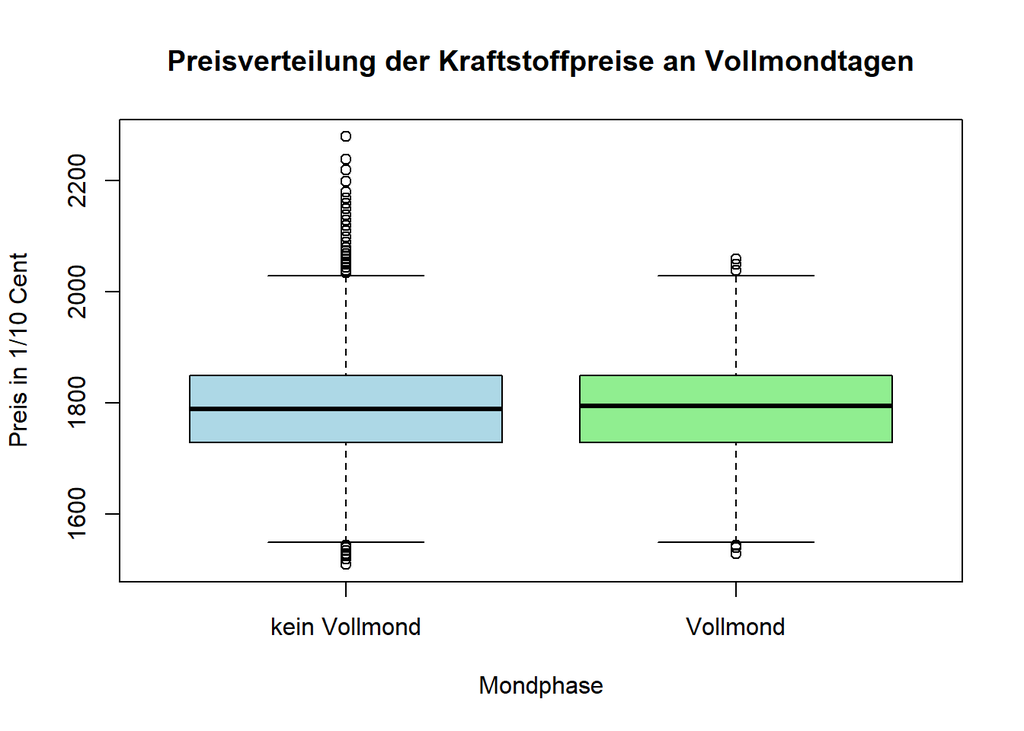

```r
# Mondphasen werden importiert
mondphasen <- read.csv("moonphases2023Berlin.csv", header = TRUE, sep = ",", dec = ".", row.names = NULL)
mondphasen$date <- as.Date(mondphasen$date, format = "%m/%d/%Y")
# Daten werden nach Mondphasen gruppiert
datensatz$mondphase <- ifelse(datensatz$date %in% mondphasen$date, "Vollmond", "kein Vollmond")
# Anzahl datenpunkte für Vollmond und kein Vollmond
sum_Full <- sum(datensatz$mondphase == "Vollmond")
sum_nFull <- sum(datensatz$mondphase == "kein Vollmond")
# Boxplot der durchschnittlichen Preise für E5, E10 und Diesel an Vollmondtagen
boxplot(cbind(datensatz$e5_median, datensatz$e10_median, datensatz$diesel_median) ~ datensatz$mondphase, data = datensatz, main = "Preisverteilung der Kraftstoffpreise an Vollmondtagen", ylab = "Preis in 1/10 Cent", col = c("lightblue", "lightgreen"), names = c("kein Vollmond", "Vollmond"), xlab = "Mondphase")
```

Die Boxplots zeigen die durchschnittlichen Preise für E5, E10 und Diesel an Vollmondtagen im Vergleich zu den Preisen an anderen Tagen. Der blaue Boxplot repräsentiert die Preise an Tagen ohne Vollmond, während der grüne Boxplot die Preise an Vollmondtagen darstellt. Es ist zu erkennen, dass die Preise an Vollmondtagen nicht höher sind als an anderen Tagen. Dies deutet darauf hin, dass die Kraftstoffpreise in Berlin nicht von den Mondphasen beeinflusst werden. Beim Boxplot der durchschnittlichen Preise für E5, E10 und Diesel an nicht Vollmondtagen sind deutlich mehr Ausreißer vorhanden als an Vollmondtagen. Dies wird daran liegen, dass wir deutlich mehr Datenpunkte für nicht Vollmondtage haben. Im Vergleich: für Vollmondtagen haben wir 23294 Datenpunkte und für nicht Vollmondtagen haben wir 149043 Datenpunkte.

# Zusammenfassung und Ausblick

Die Analyse der Kraftstoffpreise in Berlin konzentrierte sich auf die Muster und Schwankungen der Preise für E5, E10 und Diesel. Nach einer gründlichen Datenbereinigung, einschließlich der Korrektur fehlender Hausnummern, wurden keine weiteren Inkonsistenzen festgestellt.

Die deskriptive Analyse zeigte Unterschiede in den Preisverteilungen der Kraftstoffe. Zeitreihenanalysen verdeutlichten Schwankungen der Preise über den betrachteten Zeitraum. Diese Ergebnisse bieten wertvolle Einblicke in die Dynamik der Berliner Kraftstoffpreise im Jahr 2023.